# R Bevezetés

## 1. Mi az R?

Az R szakterület-specifikus programozási nyelv és fejlesztőkörnyezet, elsősorban statisztikai számításokhoz és ábrázolásokhoz használatos. Az R kiemelkedően jól teljesít adattárolási és számítási téren, kiemelkedően az alábbi területeken:

- Mátrixműveletek, tömbök kezelése
- A külső könyvtárak segítségével hatalmas tudástárhoz és eszközkészlethez jutunk az R közvetítésével
- Adatábrázolási lehetőségek
- Minden szükséges funkcionalitást biztosító interpretált programnyelv

A legfrisebb R verzió az [R 4.2.1](https://cran.r-project.org/), ami ingyenesen letölthető. Szintén ingyenesen letölthető az [R Studio](https://rstudio.com/products/rstudio/download/) fejlesztőkörnyezet, ami megkönnyítvi a programkódok írását R nyelven. Például automatikus kódkiegészítést tartalmaz. Az órákon ezt a környezetet fogjuk használni.

**Az R és az R studio nem összekeverendő egymással, az R Studio integrált fejlesztőkörnyezetet biztosít az R, mint programnyelv számára!**

## 2. Programozási alapelvek

Mivel az R egy programnyelv, így elengedhetetlen, hogy a használata előtt némi programozási alapvetésekkel tisztában legyünk.

Mint talán más tárgyban volt is szó róla, a mai számítógépek alapvetően a Neumann-elvek szerint működnek.

A mi szempontunkból ez csak annyit jelent, hogy a számítógépet alapvetően *utasítások* végrehajtására használjuk programozás során: pl. számold ki ezt, vagy rajzold ki amazt. A programozás kihívása, hogy a gépállat felfogása nagyon nehéz, ezért az utasításokat nagyon konkrétan meg kell neki fogalmazni. Ehhez a megfogalmazáshoz adnak segítséget a különböző programnyelvek, így az R is.

A Neumann-elvek szerint a programnyelven kiadott utasításokat a számítógépben a *processzor* (Central Processing Unit, CPU) hajtja végre. Ugyanakkor az utasítások végrehajtásához a gépnek adatokat is fejben kellhet tartania (mondjuk átlag számítás során nem állt tudnia milyen számok átlagát számoljuk ki). Ezeket az adatokat nem meglepő módon a *memóriájában* (Random Access Memory, RAM) tárolja a gép. A gépállattal való kommunikációhoz szükségvan valami beviteli = input eszközre (billentyűzet, egér) és az utasítások eredményének megjelenítéséhez kell egy kimieneti = output eszköz (monitor) is.

És…ennyi! Alapvetően a modern számítógépek ennyi alkotóelemből állnak (a háttértár programozás szempontjából irreleváns). Mindez egy cuki ábrán (a processzor belső felépítése minket jelenleg nem érdekel):

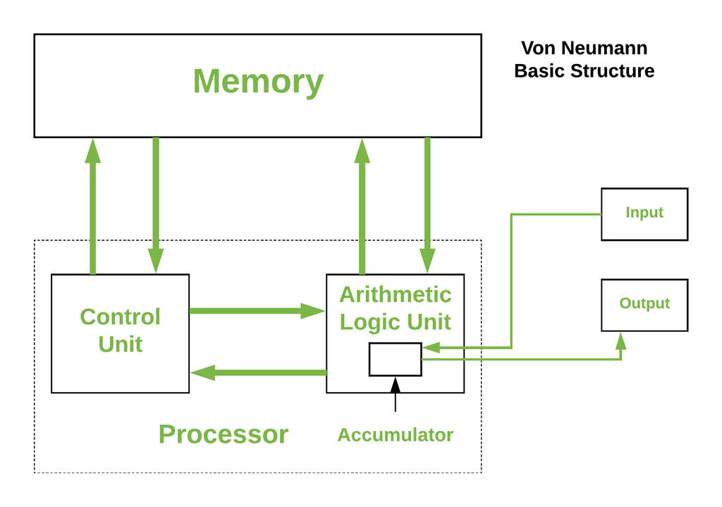

Számítógép vásárlás szempontjából is alapvetően a CPU és a RAM határozza meg mennyire gyors a gép: minél nagyobb a CPU órajele (GHz) és minél több magja van, annál több utasítást tud végrehajtani a gép egy adott idő alatt, és minél nagyobb a RAM mérete (GB) annál több adatot tud egyszerre fejben tartani. Talán nem ér minket meglepetésként, ha azt mondom, hogy a *statisztikai számítások alapvetően RAM igényesek* (mert sok adattal dolgoznak). 16-32 GB már kell, hogy komolyabb statisztikai modelleket gyorsan tudjunk futtatni egy valós vállalati adattáblán (ami általában több, mint 1 millió rekroddal és minimum 30-40 oszloppal = változóval rendelkezik).

## 3. Az R Studio felülete

Amikor feltelepítettük az alap R-t és az R Studio-t a gépünkre, akkor az R Studio-t indítsuk el. Indítás után az alábbihoz hasonló képernyőkép fogad minket:

[figure not shown]

Az R kódokat R Studio-ban *.R* kiterjesztésű szkriptfájokban fogjuk írni. Egy ilyet az alább látható módon lehet létrehozni:

[video not shown]

A szkriptfájlba írhatjuk a gépállatnak szóló utasításainkat R nyelven. Az utasítások végrehajtását a szkript fájl jobb felső sarkában lakó **Run** gomb megtaposásával tudjuk kérni a géptől, aki az utasítás eredményét alul, a *Console* felületen köpi ki. Alapesetben az R mindig azt az utasítást hajtja végre a **Run** gomb megnyomásakor, amiben éppen a villogó kurzorral álltunk. Egy példában számoltassuk ki az R-rel, hogy mennyi 3+2:

[video not shown]

Több utasítást is végre tudunk hajtatni a géppel egyszerre. Csak jelöljük ki a szkriptben a végrehajtandó utasításokat, és így kijelölés után tapossuk meg a **Run** gombot! Egy utasítást több sorba is írhatunk, de egy új utasítás mindig új sorban kezdődjön! Érdemes egy üres sort is hagyni az előző utasítás vége után!

Számoltassunk akkor most ki az R-rel egyszerre két dolgot is: mennyi 3+2 és mennyi 3*2:

[video not shown]

Ezek után a jegyezetek további részében a feladatok elvégzéséhez szükséges R kódrészleteket és azok eredményét az alábbi módon jelölöm:

```r
3+2
```

```
## [1] 5
```

```r
3*2
```

```
## [1] 6
```

## 4. Working Directory

Mielőtt belevágunk az R mélyebb rejtelmeibe van még egy fontos dolog, amiről még szót kell ejteni: a *Working Directory* kérdéséről. A *Working Directory* az a mappa, amibe az R minden *.R* kiterjesztésű szkriptfájlunkat alapértelmezetten menteni akarja. Továbbá, alapértelmezés szerint minden fájlt innen akar a memóriába tölteni. Az R Studio jobb alsó sarkában lévő részen lehet kiválasztani és beállítani, hogy melyik mappa legyen a *Working Directory*. Ezek után minden fájlunk alapból ide fog mentődni, és minden adattáblát ide rakjunk be, amivel majd az R-ben dolgozni akarunk! A *Working Directory* beállításához az R Studio jobb alsó sarokában lévő résznél található **…** gombot megnyomva kereshetünk mappát. Miután a mappaválasztás megvan, akkor ugyan ennél a résznél található **More –> Set As Working Directory** gombot nyomjuk még le a balpatkánnyal. Ez a műveletsor az alábbi R kódot generálja (nyilván mindenkinél más lesz az idézőjelek közti útvonal):

```r
setwd("C:/Users/lacko/Desktop")
```

Ezt a fenti utasítást érdemes az aktuális szkriptfájl elejére bemásolni, és utána az R Studio indításakor mindig ennek az utasításnak a megfuttatásával kezdeni a munkát, hogy az R a megfelelő helyen keresse a fájlainkat. Természetesen, a fenti utasítás idézőjelek közti részének átírásával és lefuttatásával is beállítható a *Working Directory*.

Az R Studio jobb alsó sarkában található résznél automatikusan el is navigálhatunk az aktuális *Working Directory*-ba a **More –> Go To Working Directory** gomb segítségével.

Az egész *Working Directory*-val kapcsolatos okfejtés működésben megnézhető a következő videón:

[video not shown]

Ha és amennyiben a *.R* kiterjesztésű szkriptfájlunk mentése során a gépállat rákérdez, hogy milyen karakterkódolással (*Character Encoding*) szeretnénk azt menteni, akkor az **ISO-8859-2** szabványt válasszuk, mert az tuti jól kezeli a magyar érkezeteket is:

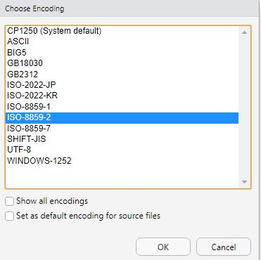

## 5. Alapvető R adattípusok és adatszerkezetek

Eddig az R-re csak utasításokat hajtattunk végre, de a memóriában (RAM-ban) nem tároltattunk el még vele semmit.  
Most itt az idő! Az utasítások eredményét a `<-` szimbólummal tudjuk a memóriába valamilyen szimpatikus néven elmenteni.

### 5.1. Egyszerű adattípusok

Mentsük el a 3+2 eredményét egy `osszeg` névre hallgató R objektumba: `osszeg <- 3+2`. Az utasítás végrehajtásának hatására az `osszeg` objektum megjelenik az R Studio *jobb felső* sarkában lévő résznél (az R nyelve és lokalizációja angol, így ne akarjunk ékezetes objektumneveket adni!). Az R Studio képernyőnek ezen részén látjuk mindig azt, hogy éppen milyen objektumok élnek a RAM-ban:

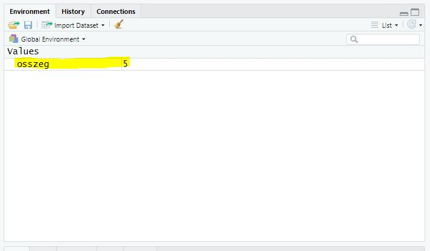

Az R memória-objektumoknak több fajtája van. A legegyszerűbbek azok, amik csak egy értéket tartalmaznak (mint nekünk az előbb az `osszeg`). Ezeket szokás néha *változó*nak is hívni. Én nem szeretem ezt az elnevezést, mert keverhető a statisztikai értelemben vett változóval, ami mindig egy statisztikai megfigyelést leíró tulajdonságot jelent (pl. munkavállaló jövdeleme).

Az R objektumoknak mindig van adattípusa is, ami leírja, hogy az adott objektumban számértékű, szöveges, dátum vagy valami egyéb jellegű adatot tárolunk-e. Ez azért marha fontos, mert az adattípustól függ, hogy mennyi hely szükséges a RAM-ban az objektum tárolásához. Érzésre megmondható talán, hogy egy szöveges adat tárolására több hely kell, mint egy egész szám tárolásához.

Az adattípusokat az `str` és a `typeof` beépített R függvényekkel lehet lekérdezni.

Ezen a ponton érdemes megemlékezni arról, hogy az R-ben léteznek függvényként működő beépített utasítások is. Ezek az úgynevezett R függvények olyan utasítások, amik a matekban megszokott $f(x)$ függvény alakot veszik fel. A függvény neve leírja, hogy a függvény milyen műveletet végeztet el a gépállattal, és a zárójelek között pedig megadjuk, hogy milyen bemeneti paramétereken (adatokon) kell elvégezni a kijelölt műveletet. Pl. ilyen függvény volt már a `setwd` is.

Gyakorlati példaként lássuk akkor R függvényekre az `str` és a `typeof` működését:

```r
osszeg <- 3+2

str(osszeg)
```

```
##  num 5
```

```r
typeof(osszeg)
```

```
## [1] "double"
```

Az eredmény alapján láthatjuk, hogy az `str` csak annyit árul el nekünk, hogy az objektumunk szám típusú cucc, de a `typeof` már azt is megmondja, hogy ez egy `double` típusú szám. A `double` típusú szám az olyan, hogy tud akár tört számot is tárolni.

Az `str` az objektum adattípusa mellett azt is eredményül adja, hogy mi az objektum aktuális értéke (a fenti példában ezért van ott az `5`).

Létezik egy `integer` nevű adattípus is, ami csak egész számokat tud tárolni. A kódban ilyenkor a szám után kell írni egy **L** betűt:

```r
egesz <- 3L

str(egesz)
```

```
##  int 3
```

```r
typeof(egesz)
```

```
## [1] "integer"
```

A mi tárgyunkban ennek nem igazán lesz jelentősége, de ha igazi *big data*-val foglalkozik az ember, akkor a RAM takarékosság miatt számít ez a különbség is!

Néhány egyéb fontosabb adattípus és megadási módjuk:

```r
szoveges <- "HelloThere" # Figyeljünk rá, hogy szöveget a kódban csak idézőjelek közé rakjunk! Mint pl. Excelben! :)

str(szoveges)
```

```
##  chr "HelloThere"
```

```r
typeof(szoveges)
```

```
## [1] "character"
```

```r
igazhamis <- TRUE

str(igazhamis)
```

```
##  logi TRUE
```

```r
typeof(igazhamis) # a logical típusnak csak két értéke lehet: TRUE vagy FALSE
```

```
## [1] "logical"
```

A fenti kódrészletben szereplő **#** jel a komment jele az R-ben. A **#** mögötti részeket a gépállat nem fogja végrehajtani, olyan lesz neki, mintha ott sem lenne. Ezzel magunknak írhatunk az R szkriptbe hasznos megjegyzéseket.

Az egyes adattípusok között tudunk konvertálni, ha van ennek van értelme. A konverzóra függvényeket tudunk használni, amik neve kivétel nélkül **as** kulcsszóval kezdődik.

Pl. számból tudunk szöveget csinálni:

```r
szam <- 1992

typeof(szam)
```

```
## [1] "double"
```

```r
szoveg <- as.character(szam)

typeof(szoveg)
```

```
## [1] "character"
```

Olyan szövegből tudunk számot csinálni, aminek tartalma tényleg egy valid szám:

```r
szoveg <- "1992"

typeof(szoveg)
```

```
## [1] "character"
```

```r
szam <- as.numeric(szoveg)

typeof(szam)
```

```
## [1] "double"
```

Tizedestörtekkel vigyázzunk! Az **R angol lokalizációt feltételez mindig**, így tizedes pontot kell alkalmazni! A tizedes vesszővel írt számot nem fogja felismerni, és hisztis hibaüzenetet dob. :( A `nemjo` változó értéke pedig üres, azaz R nyelvén `NA` lesz:

```r
nemjo <- as.numeric("3,14")
nemjo
```

```
## [1] NA
```

```r
typeof(nemjo)
```

```
## [1] "double"
```

```r
jo <- as.numeric("3.14")

jo
```

```
## [1] 3.14
```

```r
typeof(szam)
```

```
## [1] "double"
```

### 5.2. Összetett adatszerkezetek

#### Vektorok

Egyszerre több értéket tartalmazó objektumot is fel tudunk venni az R memóriájába a `c` függvénnyel. Ennek az objektumnak a neve **vektor**:

```r
sokszam <- c(3.14, 2.67, 88, 1234)

str(sokszam)
```

```
##  num [1:4] 3.14 2.67 88 1234
```

```r
typeof(sokszam)
```

```
## [1] "double"
```

Vegyük észre, hogy mindkét függvény azt mondja, hogy az új objektumunk szám, illetve double típusú. Ez amiatt van, mert a **vektor objektum csak egyféle adattípusból származó értékek sorozatát képes tárolni**!

Amennyiben eltérő adattípusú adatokat szeretnénk vektorban tárolni, akkor az R mindent átkonvertál a legáltalánosabb adattípusra, ami a szöveg (`character`):

```r
sokszam_sokszoveg <- c(88, 42, "Hello", 1992, 9, "There", "Friend", 11)

str(sokszam_sokszoveg)
```

```
##  chr [1:8] "88" "42" "Hello" "1992" "9" "There" "Friend" "11"
```

```r
typeof(sokszam_sokszoveg)
```

```
## [1] "character"
```

Ezek után nézzük meg hogyan lehet különböző műveleteket végezni a vektorokkal!

Kérjük le, hogy egy vektor hány elemet tartalmaz:

```r
sokszam <- c(3.14, 2.67, 88, 1234, 42.5)

length(sokszam)
```

```
## [1] 5
```

Kérjük le a 3. elemet:

```r
sokszam[3]
```

```
## [1] 88
```

Kérjünk le minden elemet 2-től 4-ig:

```r
sokszam[2:4]
```

```
## [1]    2.67   88.00 1234.00
```

Kérjük le a 2. és 4. elemeket! Figyeljük meg, hogy ekkor a hivatkozást is vektorként adjuk meg:

```r
sokszam[c(2,4)]
```

```
## [1]    2.67 1234.00
```

Válasszunk ki minden elemet, csak a 3-at ne:

```r
sokszam[-3]
```

```
## [1]    3.14    2.67 1234.00   42.50
```

A hecc kedvéért nézzük meg mit ad vissza gépállat, ha nem létező elemet kérünk le:

```r
sokszam[6]
```

```
## [1] NA
```

Üres értéket (`NA`)!

Rendezzük sorba a számokat tartalmazó vektor elemeit:

```r
order(sokszam)
```

```
## [1] 2 1 5 3 4
```

```r
sokszam[order(sokszam)]
```

```
## [1]    2.67    3.14   42.50   88.00 1234.00
```

Rendezzük sorba a számokat tartalmazó vektor elemeit csökkenő sorrendbe és mentsük el az eredményt egy új objektumba:

```r
rendezett <- sokszam[order(sokszam, decreasing = TRUE)]
rendezett
```

```
## [1] 1234.00   88.00   42.50    3.14    2.67
```

Figyeljük meg, hogy a sorbarendezést megvalósító `order` függvénynek elérhető egy második paramétere, ami a sorbarendezés irányát adja meg. Azt, hogy egy függvénynek mennyi és milyen paraméterei vannak, az legegyszerűbben az [R nyelv online dokumentációjából](https://www.rdocumentation.org/) lehet kideríteni, ahol a függvény nevére kell rákeresni.

Szép szóval azt szokás mondani, hogy a dokumentáció megadja, hogy az egyes R függvényeket milyen milyen paraméterezéssel lehet *meghívni*.

A dokumentáció használata során nagyon figyeljünk arra, hogy az R egy **case-sensitive** nyelv!! Ez azt jelenti, hogy az utosításokban és függvények nevében számít a kis-nagy betű!! Tehát, az `order` függvény **nem** ugyan az, mint az `Order` függvény!!

#### Listák

Különböző típusú objektumokból álló sorozat tárolására alkalmas a **lista** (`list`) objektum:

```r
sokszam_sokszoveg <- c(88, 42, "Hello", 1992, 9, "There", "Friend", 11)
sokszam <- c(3.14, 2.67, 88, 1234, 42.5)
igazhamis <- TRUE
koszontes <- "Halika"


feketelista <- list(sokszam_sokszoveg, sokszam, igazhamis, koszontes)

str(feketelista) # a függvény megmutatja a lista elemeit is $ jelekkel felsorolva
```

```
## List of 4
##  $ : chr [1:8] "88" "42" "Hello" "1992" ...
##  $ : num [1:5] 3.14 2.67 88 1234 42.5
##  $ : logi TRUE
##  $ : chr "Halika"
```

```r
typeof(feketelista) # ez csak simán visszaadja, hogy az objektum lista típusú
```

```
## [1] "list"
```

A lista elemeinek száma továbbra is lekérhető a `length` függvénnyel.

Azonban, ha a lista egy elemét akarjuk kiszedni, akkor trükközni kell. Ugyanis a vektoroknál használatos módszer nem működik:

```r
feketelista[2]
```

```
## [[1]]
## [1]    3.14    2.67   88.00 1234.00   42.50
```

```r
typeof(feketelista[2])
```

```
## [1] "list"
```

A `feketelista[2]` objektum még mindig egy lista, **nem pedig egy számokat tartalmazó vektor**!

Ha tényleg a `sokszam` objektumot akarjuk kiszedni a listából, akkor ezt kell csinálni:

```r
feketelista[[2]]
```

```
## [1]    3.14    2.67   88.00 1234.00   42.50
```

```r
typeof(feketelista[[2]]) # ez itt már tényleg egy szám típusú vektor, ahogy kell
```

```
## [1] "double"
```

Ha ez marha körülményesnek tűnik, akkor azt is csinálhatom, hogy úgy hozom létre a listát, hogy az egyes elemeinek külön neveket adok:

```r
sokszam_sokszoveg <- c(88, 42, "Hello", 1992, 9, "There", "Friend", 11)
sokszam <- c(3.14, 2.67, 88, 1234, 42.5)
igazhamis <- TRUE
koszontes <- "Halika"


feketelista <- list(egyeske = sokszam_sokszoveg, ketteske = sokszam,
                    harmaska = igazhamis, negyeske = koszontes)

str(feketelista)
```

```
## List of 4
##  $ egyeske : chr [1:8] "88" "42" "Hello" "1992" ...
##  $ ketteske: num [1:5] 3.14 2.67 88 1234 42.5
##  $ harmaska: logi TRUE
##  $ negyeske: chr "Halika"
```

Ez az elnevezősdi a lista elemeivel azért jó, mert ahogy a fenti `str` függvény eredménye is sugallja, a lista elemeit nem csak sorszámukkal, hanem nevükkel is ki lehet szedni a “fő” lista objektumból. Nem meglepő módon a dollárjel segítségével.

Szedjük akkor ki a második elemet a `feketelista` objektumból, aminek ugye a neve az, hogy `ketteske`:

```r
feketelista$ketteske
```

```
## [1]    3.14    2.67   88.00 1234.00   42.50
```

```r
typeof(feketelista$ketteske)
```

```
## [1] "double"
```

Az eredmény, várakozásainknak megfelelően egy szám (konkrétan `double`) típusú vektor, 5 elemmel.

Mielőtt tovább robogunk, töröljük ki a memóriából az eddig létrehozott R objetumokat! Ezt legegyszerűbben R Studio-ban a jobb felső sarokban lévő részen található **seprű** gomb megtaposásával lehet elérni:

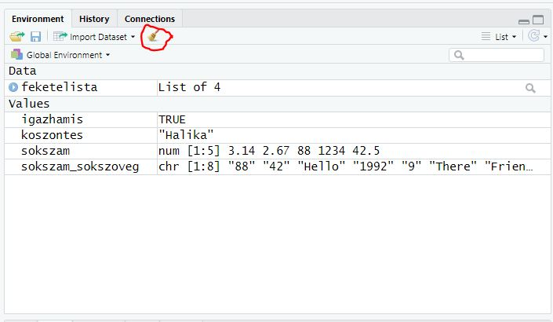

## 6. Adattáblák kezelése R-ben

R-be a legkönnyebben talán **csv** kiterjesztésű állományként tárolt adattáblákat lehet beolvasni a `read.csv` függvény segítségével. A **csv** állományok valójában olyan **txt** fájlok, amikben egy táblázat szerepel úgy, hogy az oszlophatárokat **vesszők** jelzik! Innen is a név: *comma separated values = csv*

**FIGYELEM!** A függvény az alábbi struktúrát várja el a beolvasandó **csv** fájlban lévő táblázattól:

- az oszlopok vesszővel elválasztottak
- a tört számok tizedes pontot használnak
- a szöveges adatok idézőjelek között vannak

Ha angol nyelvű oldalról töltünk le adatokat *csv*-ben (pl. [Kaggle](https://www.kaggle.com/)), akkor a fenti követelményeknek szinte biztosan meg fognak felelni.

A beolvasandó adattáblától az R elvárja azt a logikai felépítést, hogy a tábla soraiban legyenek a statisztikai megfigyelési egységeink (emberek, országok, lakások, autók stb.) és az oszlopokban pedig a megfigyeléseket leíró tulajdonságok, azaz változók/ismérvek (ember kora, ország GDP-je, autó márkája stb.).

A Moodle-n található COVID_0326.csv fájl megfelel a fenti követelményeknek, és a Föld 100 országára, mint megfigyelési egységekre nézve tartalmazza az alábbi 9 változó adatait:

- Country: ország neve
- Pop: ország népessége (fő)
- PopDens: népsűrűség (fő/km2)
- Prop_UrbanPop: Városi népesség aránya 2019-ben (%)
- PressLiberty: Sajtószabadsági index 2019-ben (alacsonyabb = szabadabb sajtó)
- PerCapita_HealthExp_2016: Egy főre jutó eüg-i kiadások, vásárlóerő-paritáson számolva (2016)
- COVID19_CasesPerMillion: Egymillió főre jutó COVID-19 fertőzöttek száma 2020.03.26-án
- ConstitutionalForm: államforma
- HeadOfState: államfő jogkörei (hatalmat gyakorol vagy csak reprezentatív szerepkörű)

Mint láthatjuk a változók leírásából, a Country, ConstitutionalForm és HeadOfState változók mérési skálája *nominális*, a többi változóké pedig *arány*.

Olvassuk akkor be az R memóriájába ezt a táblát a a `read.csv` függvénnyel egy `COVID` nevű objektumba:

```r
COVID <- read.csv("COVID_0326.csv")
# ez csak akkor működik, ha a fájl a korábban kijelölt Working Directory-ban lakik!!
```

Ha minden oké, akkor látjuk, hogy mejelent a memóriában egy `COVID` nevű adattábla, ami 100 megfigyelési egységet (*observations*-t = obs.) tartalmaz 9 változóról (*variables*), ahogy kell:

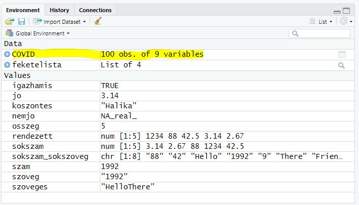

Nézzük meg milyen struktúrában is tárolta le az R ezt a `COVID` objektumot a RAM-ban:

```r
typeof(COVID)
```

```
## [1] "list"
```

```r
str(COVID)
```

```
## 'data.frame':    100 obs. of  9 variables:
##  $ Country                 : chr  "Afghanistan" "Albania" "Algeria" "Argentina" ...
##  $ Pop                     : int  38928346 2877797 43851044 45195774 2963243 25499884 10139177 9449323 11589623 397628 ...
##  $ PopDens                 : int  60 105 18 17 104 3 123 47 383 17 ...
##  $ Prop_UrbanPop           : int  25 63 73 93 63 86 56 79 98 46 ...
##  $ PressLiberty            : num  27.7 29.8 45.8 28.3 28.7 ...
##  $ PerCapita_HealthExp_2016: num  163 760 998 1531 877 ...
##  $ COVID19_CasesPerMillion : num  2.41 60.46 8.37 11.11 97.87 ...
##  $ ConstitutionalForm      : chr  "Republic" "Republic" "Republic" "Republic" ...
##  $ HeadOfState             : chr  "Executive" "Ceremonial" "Executive" "Executive" ...
```

A `typeof` szerint ő egy lista, de az `str` szerint ez egy `data frame`, bár a dollárjelek miatt nagyon hasonló az eredmény, mintha tényleg egy listára eresztettük volna rá a `str` függvényt.

Nos, a válasz az, hogy **a `data frame` típusú objektum**, amiben az R az adattáblákat tárolja **egy azonos hosszúságú vektorokból álló lista**! Tehát a lista egy eleme az valójában a tábla egy oszlopa. Ez látszik a dollárjelek utáni nevekből is.

### 6.1. A data frame objektumon végezhető alapműveletek

Nézzük meg milyen alapműveleteket tudunk végezni a `data frame` objektumokon!

Bele tudunk nézni az első néhány sorába (alapjáraton az első 6-ba):

```r
head(COVID) # alapértemezésben az első 6 sort mutatja
```

```
##       Country      Pop PopDens Prop_UrbanPop PressLiberty
## 1 Afghanistan 38928346      60            25     27.66757
## 2     Albania  2877797     105            63     29.83647
## 3     Algeria 43851044      18            73     45.75159
## 4   Argentina 45195774      17            93     28.30321
## 5     Armenia  2963243     104            63     28.74149
## 6   Australia 25499884       3            86     16.54625
##   PerCapita_HealthExp_2016 COVID19_CasesPerMillion         ConstitutionalForm
## 1                    162.8                2.414693                   Republic
## 2                    759.7               60.462917                   Republic
## 3                    998.2                8.369242                   Republic
## 4                   1531.0               11.107233                   Republic
## 5                    876.9               97.865750                   Republic
## 6                   4529.9              110.196580 Constitutional\xa0monarchy
##   HeadOfState
## 1   Executive
## 2  Ceremonial
## 3   Executive
## 4   Executive
## 5  Ceremonial
## 6  Ceremonial
```

```r
head(COVID, n=3) # ez már csak az első 3 sort írja ki
```

```
##       Country      Pop PopDens Prop_UrbanPop PressLiberty
## 1 Afghanistan 38928346      60            25     27.66757
## 2     Albania  2877797     105            63     29.83647
## 3     Algeria 43851044      18            73     45.75159
##   PerCapita_HealthExp_2016 COVID19_CasesPerMillion ConstitutionalForm
## 1                    162.8                2.414693           Republic
## 2                    759.7               60.462917           Republic
## 3                    998.2                8.369242           Republic
##   HeadOfState
## 1   Executive
## 2  Ceremonial
## 3   Executive
```

Le tudjuk kérni a kódból a tábla a sorainak és oszlopainak a számát:

```r
ncol(COVID)
```

```
## [1] 9
```

```r
nrow(COVID)
```

```
## [1] 100
```

Ki tudjuk választani 42. sor 7. oszlopát igen sokféleképpen:

```r
COVID[42,7] # ez kicsit mátrixműveletes logika: [sor,oszlop] hivatkozás
```

```
## [1] 85.57952
```

```r
COVID[42,"COVID19_CasesPerMillion"] # az oszlopot szám helyett a nevével is lehet hivatkozni
```

```
## [1] 85.57952
```

```r
COVID$COVID19_CasesPerMillion[42] # itt eleve azt mondom, hogy kiszedjük a COVID19_CasesPerMillion nevű oszlopot (vagyis listaelemet) a listából a $ jellel, és annak nézzük meg a 42. elemét
```

```
## [1] 85.57952
```

Ki tudjuk választani az egész 42. sort:

```r
COVID[42,] # ilyenkor az oszlop hivatkozást hagyjuk simán üresen, de a vesszőt még írjuk be!
```

```
##    Country      Pop PopDens Prop_UrbanPop PressLiberty PerCapita_HealthExp_2016
## 42  Greece 10423054      81            85     29.08402                   2261.2
##    COVID19_CasesPerMillion ConstitutionalForm HeadOfState
## 42                85.57952           Republic  Ceremonial
```

Vagy az egész 7. oszlopot:

```r
COVID[,7] # ilyenkor a sor hivatkozást hagyjuk simán üresen, de a vesszőt még írjuk be!
```

```
##   [1]   2.414693  60.462917   8.369242  11.107233  97.865750 110.196580
##   [7]  12.032535   9.101181 537.981261   5.029827   2.591990   3.683708
##  [13]  58.217171  14.043132  37.994112   7.271589   5.741982   2.825299
##  [19] 107.121602  68.319014  56.823907   9.649609  45.346417 120.576810
##  [25]   5.915271 120.925094 349.262681  11.133603  44.985624  79.521380
##  [31]   4.837083   2.004254   8.553192 405.567889   5.577587 172.901717
##  [37] 452.725762   3.145030  19.803633 524.420300   4.248069  85.579524
##  [43]   6.356859   5.250082  27.017652   3.264800   9.497174 368.383725
##  [49] 311.130392   8.780322  10.966468  20.777930   5.911580   6.744127
##  [55] 129.360756  53.915899 109.834040  62.751037  24.049846 303.481201
##  [61]  63.690862   3.684091  43.877448   3.355408 109.861066   7.450442
##  [67]   3.148484 435.836346  58.686505  21.344818   5.437038 129.323321
##  [73]   5.748304  17.590761   6.451844  32.261805 347.563121 190.555328
##  [79]  53.488748   3.860343  29.068873   6.270930  43.949147  71.176548
##  [85]  41.394656 270.330332  15.630087   4.950206  13.637169 281.208583
##  [91]  14.971351   2.778206  46.445557  16.668614  43.028695   4.481663
##  [97]  33.669006 173.997556  62.468874   2.240866
```

```r
COVID[,"COVID19_CasesPerMillion"]
```

```
##   [1]   2.414693  60.462917   8.369242  11.107233  97.865750 110.196580
##   [7]  12.032535   9.101181 537.981261   5.029827   2.591990   3.683708
##  [13]  58.217171  14.043132  37.994112   7.271589   5.741982   2.825299
##  [19] 107.121602  68.319014  56.823907   9.649609  45.346417 120.576810
##  [25]   5.915271 120.925094 349.262681  11.133603  44.985624  79.521380
##  [31]   4.837083   2.004254   8.553192 405.567889   5.577587 172.901717
##  [37] 452.725762   3.145030  19.803633 524.420300   4.248069  85.579524
##  [43]   6.356859   5.250082  27.017652   3.264800   9.497174 368.383725
##  [49] 311.130392   8.780322  10.966468  20.777930   5.911580   6.744127
##  [55] 129.360756  53.915899 109.834040  62.751037  24.049846 303.481201
##  [61]  63.690862   3.684091  43.877448   3.355408 109.861066   7.450442
##  [67]   3.148484 435.836346  58.686505  21.344818   5.437038 129.323321
##  [73]   5.748304  17.590761   6.451844  32.261805 347.563121 190.555328
##  [79]  53.488748   3.860343  29.068873   6.270930  43.949147  71.176548
##  [85]  41.394656 270.330332  15.630087   4.950206  13.637169 281.208583
##  [91]  14.971351   2.778206  46.445557  16.668614  43.028695   4.481663
##  [97]  33.669006 173.997556  62.468874   2.240866
```

```r
COVID$COVID19_CasesPerMillion
```

```
##   [1]   2.414693  60.462917   8.369242  11.107233  97.865750 110.196580
##   [7]  12.032535   9.101181 537.981261   5.029827   2.591990   3.683708
##  [13]  58.217171  14.043132  37.994112   7.271589   5.741982   2.825299
##  [19] 107.121602  68.319014  56.823907   9.649609  45.346417 120.576810
##  [25]   5.915271 120.925094 349.262681  11.133603  44.985624  79.521380
##  [31]   4.837083   2.004254   8.553192 405.567889   5.577587 172.901717
##  [37] 452.725762   3.145030  19.803633 524.420300   4.248069  85.579524
##  [43]   6.356859   5.250082  27.017652   3.264800   9.497174 368.383725
##  [49] 311.130392   8.780322  10.966468  20.777930   5.911580   6.744127
##  [55] 129.360756  53.915899 109.834040  62.751037  24.049846 303.481201
##  [61]  63.690862   3.684091  43.877448   3.355408 109.861066   7.450442
##  [67]   3.148484 435.836346  58.686505  21.344818   5.437038 129.323321
##  [73]   5.748304  17.590761   6.451844  32.261805 347.563121 190.555328
##  [79]  53.488748   3.860343  29.068873   6.270930  43.949147  71.176548
##  [85]  41.394656 270.330332  15.630087   4.950206  13.637169 281.208583
##  [91]  14.971351   2.778206  46.445557  16.668614  43.028695   4.481663
##  [97]  33.669006 173.997556  62.468874   2.240866
```

Több sort és oszlopot is ki tudunk választani, ha a [] közti hivatkozásokba vektorokat rakunk:

```r
COVID[c(1,50,60,80),c(1,4,7)]
```

```
##        Country Prop_UrbanPop COVID19_CasesPerMillion
## 1  Afghanistan            25                2.414693
## 50     Jamaica            55                8.780322
## 60       Malta            93              303.481201
## 80      Rwanda            18                3.860343
```

```r
COVID[c(1,50,60,80),c("Country","Prop_UrbanPop","COVID19_CasesPerMillion")]
```

```
##        Country Prop_UrbanPop COVID19_CasesPerMillion
## 1  Afghanistan            25                2.414693
## 50     Jamaica            55                8.780322
## 60       Malta            93              303.481201
## 80      Rwanda            18                3.860343
```

```r
COVID[20:30,c("Country","Prop_UrbanPop","COVID19_CasesPerMillion")] # Ha a kiválasztandó sorok követik egymást, akkor így is lehet
```

```
##               Country Prop_UrbanPop COVID19_CasesPerMillion
## 20              Chile            85               68.319014
## 21              China            61               56.823907
## 22           Colombia            80                9.649609
## 23         Costa Rica            80               45.346417
## 24            Croatia            58              120.576810
## 25               Cuba            78                5.915271
## 26             Cyprus            67              120.925094
## 27            Denmark            88              349.262681
## 28           Djibouti            79               11.133603
## 29 Dominican Republic            85               44.985624
## 30            Ecuador            63               79.521380
```

```r
COVID[20:30,1:4] # Ha a kiválasztandó oszlopok követik egymást, akkor így is lehet
```

```
##               Country        Pop PopDens Prop_UrbanPop
## 20              Chile   19116201      26            85
## 21              China 1439323776     153            61
## 22           Colombia   50882891      46            80
## 23         Costa Rica    5094118     100            80
## 24            Croatia    4105267      73            58
## 25               Cuba   11326616     106            78
## 26             Cyprus    1207359     131            67
## 27            Denmark    5792202     137            88
## 28           Djibouti     988000      43            79
## 29 Dominican Republic   10847910     225            85
## 30            Ecuador   17643054      71            63
```

Ami a legszebb ebben az egészben, hogy a **kiválasztandó sorokat logikai feltételekkel is ki tudjuk jelölni**. Magyarul tudjuk **szűrni** az adattáblát!

### 6.2. Pár példa data frame objektumban végzett szűrésre

Adjuk meg azon országok neveit, ahol 100 felett volt 2020.03.26-án az egymillió főre jutó COVID esetszám:

```r
COVID[COVID$COVID19_CasesPerMillion > 100, c("Country", "COVID19_CasesPerMillion")]
```

```
##           Country COVID19_CasesPerMillion
## 6       Australia                110.1966
## 9         Belgium                537.9813
## 19         Canada                107.1216
## 24        Croatia                120.5768
## 26         Cyprus                120.9251
## 27        Denmark                349.2627
## 34        Estonia                405.5679
## 36        Finland                172.9017
## 37         France                452.7258
## 40        Germany                524.4203
## 48        Ireland                368.3837
## 49         Israel                311.1304
## 55         Latvia                129.3608
## 57      Lithuania                109.8340
## 60          Malta                303.4812
## 65     Montenegro                109.8611
## 68    Netherlands                435.8363
## 72         Panama                129.3233
## 77       Portugal                347.5631
## 78          Qatar                190.5553
## 86       Slovenia                270.3303
## 90         Sweden                281.2086
## 98 United Kingdom                173.9976
```

Adjuk meg azon országok neveit, ahol 100 felett volt 2020.03.26-án az egymillió főre jutó COVID esetszám, **és** a városi népesség aránya legfeljebb 60%:

```r
COVID[COVID$COVID19_CasesPerMillion > 100 & COVID$Prop_UrbanPop <= 60,
      c("Country", "Prop_UrbanPop", "COVID19_CasesPerMillion")]
```

```
##     Country Prop_UrbanPop COVID19_CasesPerMillion
## 24  Croatia            58                120.5768
## 86 Slovenia            55                270.3303
```

Adjuk meg azon országok neveit, ahol az államforma abszolút monarchia, **vagy** a városi népesség aránya 35% alatti:

```r
# először megnézzük, hogy milyen lehetséges értékei vannak a ConstitutionalForm változónak a unique függvénnyel

unique(COVID$ConstitutionalForm)
```

```
## [1] "Republic"                   "Constitutional\xa0monarchy"
## [3] "Absolute monarchy"
```

```r
# a unique függvény eredményéből látjuk, hogy az abszolút monarchiák "Absolute monarchy" néven futnak a táblában

COVID[COVID$ConstitutionalForm == "Absolute monarchy" | COVID$Prop_UrbanPop < 35,
      c("Country", "Prop_UrbanPop", "ConstitutionalForm")]
```

```
##         Country Prop_UrbanPop         ConstitutionalForm
## 1   Afghanistan            25                   Republic
## 16 Burkina Faso            31                   Republic
## 17     Cambodia            24 Constitutional\xa0monarchy
## 43       Guyana            27                   Republic
## 70         Oman            87          Absolute monarchy
## 78        Qatar            96          Absolute monarchy
## 80       Rwanda            18                   Republic
## 81 Saudi Arabia            84          Absolute monarchy
## 88    Sri Lanka            18                   Republic
```

Adjuk meg Belgium, Magyarország és Horvátország népsűrűségét és 2020.03.26-i COVID esetszámait:

```r
COVID[COVID$Country %in% c("Belgium", "Hungary", "Croatia"),
      c("Country", "PopDens", "COVID19_CasesPerMillion")]
```

```
##    Country PopDens COVID19_CasesPerMillion
## 9  Belgium     383               537.98126
## 24 Croatia      73               120.57681
## 45 Hungary     107                27.01765
```

Adjuk meg azon országok nevét, államformáját és 2020.03.26-i COVID esetszámait, amik **nem** köztársaságok! Az eredményt mentsük el egy új, `NemKozt` nevű `data frame`-be, és az eredménynek csak az első 6 sorát jelenítsük meg:

```r
NemKozt <- COVID[COVID$ConstitutionalForm != "Republic",
      c("Country", "ConstitutionalForm", "COVID19_CasesPerMillion")]
# Figyeljük meg, hogy a "!=" a "nem egyenlő" jele

head(NemKozt)
```

```
##      Country         ConstitutionalForm COVID19_CasesPerMillion
## 6  Australia Constitutional\xa0monarchy              110.196580
## 9    Belgium Constitutional\xa0monarchy              537.981261
## 10    Belize Constitutional\xa0monarchy                5.029827
## 11    Bhutan Constitutional\xa0monarchy                2.591990
## 17  Cambodia Constitutional\xa0monarchy                5.741982
## 19    Canada Constitutional\xa0monarchy              107.121602
```

Adjuk meg azon országok nevét, amiknek az államformája **nem** köztársaság és **nem** is abszolút monarchia:

```r
COVID[!(COVID$ConstitutionalForm %in% c("Absolute monarchy", "Republic")),
      c("Country", "ConstitutionalForm")]
```

```
##                 Country         ConstitutionalForm
## 6             Australia Constitutional\xa0monarchy
## 9               Belgium Constitutional\xa0monarchy
## 10               Belize Constitutional\xa0monarchy
## 11               Bhutan Constitutional\xa0monarchy
## 17             Cambodia Constitutional\xa0monarchy
## 19               Canada Constitutional\xa0monarchy
## 27              Denmark Constitutional\xa0monarchy
## 50              Jamaica Constitutional\xa0monarchy
## 51                Japan Constitutional\xa0monarchy
## 52               Jordan Constitutional\xa0monarchy
## 58             Malaysia Constitutional\xa0monarchy
## 66              Morocco Constitutional\xa0monarchy
## 68          Netherlands Constitutional\xa0monarchy
## 69          New Zealand Constitutional\xa0monarchy
## 90               Sweden Constitutional\xa0monarchy
## 91             Thailand Constitutional\xa0monarchy
## 97 United Arab Emirates Constitutional\xa0monarchy
## 98       United Kingdom Constitutional\xa0monarchy
```

```r
# Figyeljük meg, hogy a "!" általánosan a "tagadás" jele
```

Persze, hogy ha bevetjük a `unique` függvényt, akkor gyorsan rájövünk, hogy ezek egyszerűen az alkotmányos monarchiák, de most a *tagadás* jelét (szép szóval opratátorát) akartam megmutatni. :)

```r
unique(COVID$ConstitutionalForm)
```

```
## [1] "Republic"                   "Constitutional\xa0monarchy"
## [3] "Absolute monarchy"
```

```r
KeresettAllamforma <- unique(COVID$ConstitutionalForm)[2]

COVID[COVID$ConstitutionalForm == KeresettAllamforma,
      c("Country", "ConstitutionalForm")] # csak, hogy lássuk: így is lehet :)
```

```
##                 Country         ConstitutionalForm
## 6             Australia Constitutional\xa0monarchy
## 9               Belgium Constitutional\xa0monarchy
## 10               Belize Constitutional\xa0monarchy
## 11               Bhutan Constitutional\xa0monarchy
## 17             Cambodia Constitutional\xa0monarchy
## 19               Canada Constitutional\xa0monarchy
## 27              Denmark Constitutional\xa0monarchy
## 50              Jamaica Constitutional\xa0monarchy
## 51                Japan Constitutional\xa0monarchy
## 52               Jordan Constitutional\xa0monarchy
## 58             Malaysia Constitutional\xa0monarchy
## 66              Morocco Constitutional\xa0monarchy
## 68          Netherlands Constitutional\xa0monarchy
## 69          New Zealand Constitutional\xa0monarchy
## 90               Sweden Constitutional\xa0monarchy
## 91             Thailand Constitutional\xa0monarchy
## 97 United Arab Emirates Constitutional\xa0monarchy
## 98       United Kingdom Constitutional\xa0monarchy
```

A fenti szűrések R kódja alapján remélhetőleg érződik már, hogy milyen kódokkal lehet logikai műveleteket kijelölni az R utasításokban:

| Kód | Jelentés |
| --- | --- |
| < | Kisebb |
| > | Nagyobb |
| == | Egyenlő |
| != | Nem Egyenlő |
| <= | Legfeljebb |
| >= | Legalább |
| & | ÉS |
| \| | VAGY |
| %in% | TARTALMAZ |
| ! | TAGADÁS |

Még két érdekes dolog a `data frame`-k kapcsán.

Először is, oszlopokat át lehet nevezni a `colnames` függvény segítségével, ami egy vektorba szedi ki az oszlopneveket:

```r
colnames(COVID) # megnézzük az oszlopneveket
```

```
## [1] "Country"                  "Pop"
## [3] "PopDens"                  "Prop_UrbanPop"
## [5] "PressLiberty"             "PerCapita_HealthExp_2016"
## [7] "COVID19_CasesPerMillion"  "ConstitutionalForm"
## [9] "HeadOfState"
```

```r
# majd a Country oszlopot (ami az 1. oszlop) átnevezzük "Orszag"-ra
colnames(COVID)[1] <- "Orszag"

# meglessük az eredményt
colnames(COVID)
```

```
## [1] "Orszag"                   "Pop"
## [3] "PopDens"                  "Prop_UrbanPop"
## [5] "PressLiberty"             "PerCapita_HealthExp_2016"
## [7] "COVID19_CasesPerMillion"  "ConstitutionalForm"
## [9] "HeadOfState"
```

Másodszor, a létező oszlopokból ki lehet számolni újakat. Pl. adjuk meg az országok területét hektárban (1 km2 = 100 ha)!

```r
COVID$Area <- (COVID$Pop / COVID$PopDens) * 100 # emlékezzünk: a népsűrűség fő/km2-ben volt megadva!

head(COVID[,c("Orszag", "Area")])
```

```
##        Orszag      Area
## 1 Afghanistan  64880577
## 2     Albania   2740759
## 3     Algeria 243616911
## 4   Argentina 265857494
## 5     Armenia   2849272
## 6   Australia 849996133
```

Egyébként ez általánosságban igaz a *vektor*okra R-ben: egyszerűen, a normális műveleti jelek és R függvények segítségével végezhetünk rajtuk matematikai műveleteket.

Adjunk meg két számítértékű vektort:

```r
egyik <- c(1,2,3,4)

masik <- c(6,7,8,9)
```

Adjuk össze és szorozzuk a két vektor elemeit páronként, sorban:

```r
egyik + masik
```

```
## [1]  7  9 11 13
```

```r
egyik * masik
```

```
## [1]  6 14 24 36
```

Emeljük négyzetre a `masik` vektor elemeit:

```r
masik^2
```

```
## [1] 36 49 64 81
```

Vegyük a két vektor szorzatösszegét az *összeg*, azaz `sum` R függvény alkalmazásával:

```r
sum(egyik * masik)
```

```
## [1] 80
```

Vegyük az `egyik` vektor elemeinek átlagát a `mean` R függvény alkalmazásával:

```r
mean(egyik)
```

```
## [1] 2.5
```

## 7. Külső csomagok telepítése és behivatkozása

Ahogyan a bevezetőben is írtam, az R egyik legvonzóbb tulajdonsága, hogy külső könyvtárak, csomagok (`library`-k) segítségével rengeteg extra függvényhez férhetünk hozzá, amik nincsenek benne az alap (base) R verzióban.

A következő feladathoz majd egy `RcmdrMisc` névre hallgató külső csomagból lesz szükségünk egy függvényre.

A 2. alkalommal pedig szükségünk lesz az alábbi csomagokra:

- readr
- psych
- ggplot2

Telepítsük őket! Ha a felugorna egy ablak, ahol országot kéne választanunk, akkor bátran válasszuk *Hungary*-t! :) Ha valamilyen oknál fogva ezzel baja lenne az R-nek, akkor *Austrira* tuti szokott működni.

```r
install.packages("RcmdrMisc")
install.packages("readr")
install.packages("psych")
install.packages("ggplot2")
```

Ha csomag telepítés során az R pirossal WARNING-okat dob vissza, azokat nyugodtan figyelmen kívül lehet hagyni. A piros szín ijesztő lehet, de amíg az üzenet elején nem szerepel az *Error* szó, csak a WARNING, addig nincs gáz! :)

Ahhoz, hogy tudjuk használni is a telepített csomagok függvényeit, be kell őket hívni az R-be a `library` paranccsal. Most hívjuk be az R-be a `RcmdrMisc` csomagot:

```r
library(RcmdrMisc)
```

A piros üzenetekkel, ha nem *Error*okat írnak, továbbra sem kell törődni.

Csomagot lehet telepíteni az R Studio jobb alsó sarkában lévő résznél található gombok segítségével is [bocsi, a videóban kicsit bénázok a *psych* szó gépelésével :)]:

[video not shown]

## 8. Gyakoriság, Osztályközök, Relatív gyakoriság, Kumulált gyakoriság, Hisztogram

A legegyszerűbb statisztikai eszköz, amivel egy statisztikai ismérvben/változóban lévő információtartalomról tömörített képet kaphatunk az a gyakorisági táblázat.  
Ez ahogy a neve is mutatja, nem csinál semmi mást, csak kilistázza a változó összes lehetséges értékét és megadja, hogy melyik érték hányszor fordul elő a vizsgált `data frame`-ben, azaz megadja a változó értékeinek *gyakoriságát*. Ez egy olyan egyszerű művelet, ami mérési skálától függetlenül alkalmazható, értelemszerűen darabszámokat nominális mérési skálájú változókra is meg tudunk határozni.

Vegyük például a nominális mérési skálájú, államforma, **ConstitutionalForm** változót. A változó értékeinek gyakoriságát a `table` függvénnyel tudjuk meghatározni.

```r
table(COVID$ConstitutionalForm)
```

```
##
##          Absolute monarchy Constitutional\xa0monarchy
##                          3                         18
##                   Republic
##                         79
```

Láthatjuk, hogy a legtöbb ország (79 db) köztársaság, míg abszolút monarchiából csak 3 van a vizsgált adatsorunkban. Tehát a vizsgált országainknak jelentős része, majdnem 79/100=4/5 része olybá tűnik, hogy köztársaságként működik, és a monarchia (még az alkotmányos is) már ritkaságnak számít manapság.

Most nézzük meg az egymilliófőre jutó COVID esetszám gyakoriságait is ugyan ezzel a függvénnyel.

```r
table(COVID$COVID19_CasesPerMillion)
```

```
##
## 2.004253643 2.240866028 2.414692882 2.591989715 2.778205917 2.825298993
##           1           1           1           1           1           1
## 3.145029909 3.148484497 3.264800372  3.35540785 3.683707928 3.684091039
##           1           1           1           1           1           1
## 3.860342684  4.24806922 4.481663389 4.837082942 4.950206295 5.029826873
##           1           1           1           1           1           1
## 5.250082108  5.43703779 5.577587024 5.741982234  5.74830446 5.911579704
##           1           1           1           1           1           1
## 5.915270722  6.27093035 6.356858796 6.451843812 6.744127053 7.271588521
##           1           1           1           1           1           1
## 7.450442367 8.369242019 8.553191944 8.780322082 9.101181111 9.497173634
##           1           1           1           1           1           1
## 9.649608942 10.96646751 11.10723317 11.13360324 12.03253479 13.63716947
##           1           1           1           1           1           1
## 14.04313223 14.97135142 15.63008726 16.66861416  17.5907609 19.80363319
##           1           1           1           1           1           1
##  20.7779296  21.3448175 24.04984608 27.01765184 29.06887315 32.26180542
##           1           1           1           1           1           1
## 33.66900557 37.99411235 41.39465555 43.02869511 43.87744756 43.94914672
##           1           1           1           1           1           1
## 44.98562396 45.34641718 46.44555723 53.48874769 53.91589852 56.82390673
##           1           1           1           1           1           1
## 58.21717077 58.68650478  60.4629166 62.46887352 62.75103698 63.69086186
##           1           1           1           1           1           1
##  68.3190138 71.17654834 79.52137992 85.57952401 97.86575046  107.121602
##           1           1           1           1           1           1
## 109.8340404 109.8610656 110.1965797 120.5768102 120.9250935 129.3233215
##           1           1           1           1           1           1
## 129.3607564 172.9017167  173.997556 190.5553282 270.3303321  281.208583
##           1           1           1           1           1           1
## 303.4812012 311.1303923 347.5631206 349.2626811  368.383725 405.5678893
##           1           1           1           1           1           1
## 435.8363459 452.7257619    524.4203 537.9812613
##           1           1           1           1
```

Ajjajj! Na, itt nem úgy néz ki, hogy megvalósult volna a statisztikai eszközök legfontosabb célja: a változóban lévő információ tömör megjelenítése. Ebből a fenti eredménytáblázatból sok hasznos következtetést nem tudunk levonni, mivel *minden esetszám egyszer fordul elő*. Ez igazából annak a következménye, hogy az egymillió főre jutó COVID esetszámnak, mint numerikus változónak az *értékkészlete nagy*.

A nagy értékkészletű numerikus változókat úgy tudjuk kezelni, és használhatóvá alakítani a gyakorisági táblát, hogy az esetszámokat *tól-ig* kategóriákba, szakszóval **osztályközökbe** soroljuk, és ezeknek a kategóriáknak vizsgáljuk a gyakoriságait. Hiszen feltehetően pl. 50-100 közötti egymillió főre jutó esetszámmal már nem csak egyetlen ország bír.

Mielőtt belevágunk, gondoljuk végig, hogy milyen elven kellene kialakítani ezeket a *tól-ig* kategóriákat, hogy jól értelmezhető módon mutasság meg a numerikus változónk **gyakorsiági eloszlásának** alakulását:

- A kilalakított *kategóriáknak = osztályközöknek* **egyenlő hosszúnak** kell lenniük. Hiszen, ha az egyik kategória nagyobb értéktartományt fed le, mint a többi, akkor abba a kategóriába értelemszerűen több elem fog beleesni, és ott nagyobb lesz a kimutatott gyakoriság.
- Az azonos hosszú kategóriák/osztályközök számának elég kicsinek kell lennie, hogy a gyakorisági tábla ne nőjön túl nagyra, és átlátható legyen, de elég nagynak is kell lennie ahhoz, hogy a gyakorisági tábla megfelelő mennyiségű információt közvetítsen a változóról. Értelemszerűen 2 db kategória létrehozása nem fedi fel a változó gyakoriságainak részletes viszonyait, és túl sok információt veszít.

Az R `RcmdrMisc` csomagjának `binnedCounts` függvénye mindezek szellemében egyenlő osztályközök mellett készíti el a gyakorisági táblát, és második pontban szereplő követelményt a **Négyzetgyökszabály** alkalmazásával teljesíti. A szabály szerint egy változó gyakorisági táblájához kialakítandó osztályközök száma ($k$) az adatok elemszámától ($N$-től) függ, egyszerűen $k=\sqrt{N}$ módon.

Próbáljuk is ki a függvényt a **COVID19_CasesPerMillion** változón:

```r
binnedCounts(COVID$COVID19_CasesPerMillion)
```

```
## Binned distribution of COVID$COVID19_CasesPerMillion
##            Count Percent
## [0, 50]       63      63
## (50, 100]     14      14
## (100, 150]     8       8
## (150, 200]     3       3
## (200, 250]     0       0
## (250, 300]     2       2
## (300, 350]     4       4
## (350, 400]     1       1
## (400, 450]     2       2
## (450, 500]     1       1
## (500, 550]     2       2
## Total        100     100
```

```r
(max(COVID$COVID19_CasesPerMillion)-min(COVID$COVID19_CasesPerMillion))/10
```

```
## [1] 53.5977
```

Emiatt az R függvényünk inkább kikerekíti a lépésköz hosszát 50-re, és *bevállal** egy 11. osztályközt.

Ha és amennyiben nem tetszik nekünk a Négyzetgyökszabályból adódó $k$, bármikor felülírhatjuk a `binnedCounts` függvény `breaks` paraméterén keresztül. Pl. ha mindenáron csak 6 osztályközt szeretnénk:

```r
binnedCounts(COVID$COVID19_CasesPerMillion, breaks = 6)
```

```
## Binned distribution of COVID$COVID19_CasesPerMillion
##            Count Percent
## [0, 100]      77      77
## (100, 200]    11      11
## (200, 300]     2       2
## (300, 400]     5       5
## (400, 500]     3       3
## (500, 600]     2       2
## Total        100     100
```

De térjünk is vissza az eredeti verzióra:

```r
binnedCounts(COVID$COVID19_CasesPerMillion)
```

```
## Binned distribution of COVID$COVID19_CasesPerMillion
##            Count Percent
## [0, 50]       63      63
## (50, 100]     14      14
## (100, 150]     8       8
## (150, 200]     3       3
## (200, 250]     0       0
## (250, 300]     2       2
## (300, 350]     4       4
## (350, 400]     1       1
## (400, 450]     2       2
## (450, 500]     1       1
## (500, 550]     2       2
## Total        100     100
```

Az eredmények alapján elmondhatjuk, hogy a 100-ból 63 országban az egymillió főre jutó COVID esetszám 50 alatti volt 2020.03.26-án. 4 országban volt az esetszám 300-350 eset/millió fő között. A **Percent** oszlopban láthatjuk, hogy a teljes elemszám hány százalékát teszi ki az adott sor/kategória gyakorisága. Ez az oszlop a **relatív gyakoriság**ok oszlopa. Most ez egyezik a *“nyers” gyakoriságok*at mutató **Count** oszlop értékeivel, mivel a teljes elemszám a **COVID** táblázatban $N=100$, és hát pl. $\frac{14}{100}=0.14=14\%$. :)

Ha a gyakorisági táblázatot `data frame`-é konvertálva elmentjük a memóriába, akkor bővíthetjuk a táblázatot egy úgynevezett **kumulált gyakoriság** oszloppal is az R `cumsum` függvénye segítségével.

```r
# gyakorisági tábla mentése data frame-ként
gyak_tabla <- as.data.frame(binnedCounts(COVID$COVID19_CasesPerMillion))
```

```
## Binned distribution of COVID$COVID19_CasesPerMillion
##            Count Percent
## [0, 50]       63      63
## (50, 100]     14      14
## (100, 150]     8       8
## (150, 200]     3       3
## (200, 250]     0       0
## (250, 300]     2       2
## (300, 350]     4       4
## (350, 400]     1       1
## (400, 450]     2       2
## (450, 500]     1       1
## (500, 550]     2       2
## Total        100     100
```

```r
# oszlopnév "szépítése"
colnames(gyak_tabla) <- "Gyakorisag"

# kumulált gyakoriságok számítása új oszlopba
gyak_tabla$Kumulalt_Gyak <- cumsum(gyak_tabla$Gyakorisag)

# eredmény megtekintése
gyak_tabla
```

```
##            Gyakorisag Kumulalt_Gyak
## [0, 50]            63            63
## (50, 100]          14            77
## (100, 150]          8            85
## (150, 200]          3            88
## (200, 250]          0            88
## (250, 300]          2            90
## (300, 350]          4            94
## (350, 400]          1            95
## (400, 450]          2            97
## (450, 500]          1            98
## (500, 550]          2           100
```

Voilá! Amit az új, **Kumulalt_Gyak** oszlop megmutat az az *adott kategória felső határa alatt lévő elemek száma/gyakorisága*.  
Tehát, ha pl. a 3. sort nézem, akkor azt mondhatom 8 országban van az egymillió főre jutó COVID esetszám 100-150 eset/millió fő között, de 85 db országban van az esetszám 150 eset/millió fő **alatt**. Nyilván ezt a kumulálás műveletet hasonlóan el lehet játszani a relatív gyakoriságokra is, csak először azokat külön bele kell rakni még a **gyak_tabla** nevű `data frame`-be:

```r
# gyakorisági tábla bővítése relatív gyakoriságokkal
gyak_tabla$Rel_Gyak <- gyak_tabla$Gyakorisag / sum(gyak_tabla$Gyakorisag)


# kumulált relatív gyakoriságok számítása új oszlopba
gyak_tabla$Kumulalt_Rel_Gyak <- cumsum(gyak_tabla$Rel_Gyak)

# eredmény megtekintése
gyak_tabla
```

```
##            Gyakorisag Kumulalt_Gyak Rel_Gyak Kumulalt_Rel_Gyak
## [0, 50]            63            63     0.63              0.63
## (50, 100]          14            77     0.14              0.77
## (100, 150]          8            85     0.08              0.85
## (150, 200]          3            88     0.03              0.88
## (200, 250]          0            88     0.00              0.88
## (250, 300]          2            90     0.02              0.90
## (300, 350]          4            94     0.04              0.94
## (350, 400]          1            95     0.01              0.95
## (400, 450]          2            97     0.02              0.97
## (450, 500]          1            98     0.01              0.98
## (500, 550]          2           100     0.02              1.00
```

Tehát, a bővített tábla alapján azt mondhatjuk, hogy az országok 8%-ában van az egymillió főre jutó COVID esetszám 100-150 eset/millió fő között, de az országok 85%-ban van az esetszám 150 eset/millió fő alatt.

**Fontos tulajsonság**a a kumulált oszlopoknak, hogy a gyakorisági tábla utolsó sorában a sima kumulált gyakoriságnak mindig a *teljes elemszámmal* kell egyeznie, míg a kumulált relatív gykoriságnak mindig *100%-ra* kell az utolsó sorban kijönnie. Hiszen minden egyes adat kisebb vagy egyenlő, mint a változó maximális értéke!

A gyakorisági tábla egy grafikus megjelenítési eszköze a **hisztogram**, ami az R `hist` függvényével lekérhető egy `data frame` tetszőleges numerikus oszlopára:

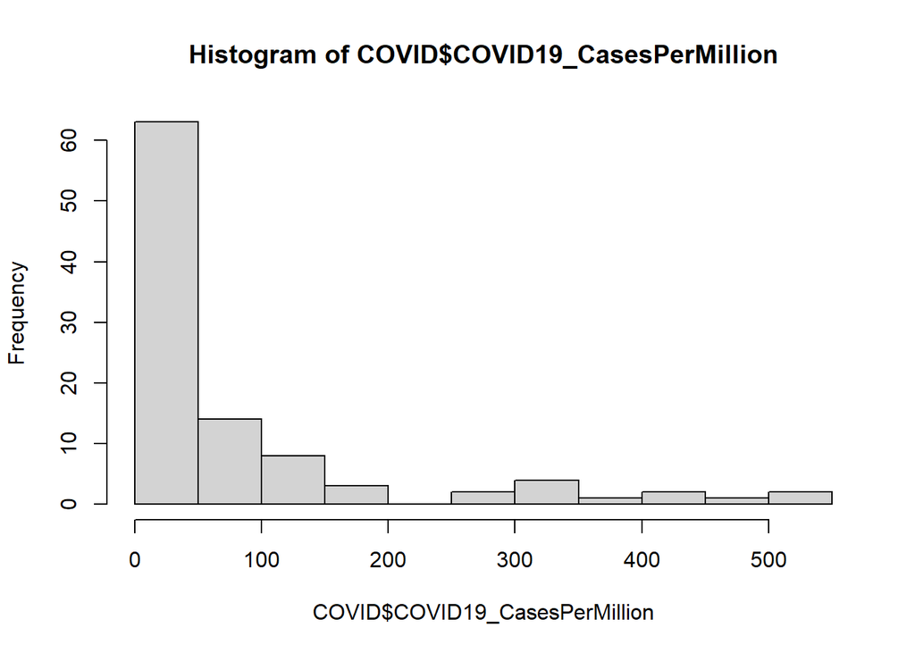

```r
hist(COVID$COVID19_CasesPerMillion)
```

Látható, hogy a hisztogram egy oszlopdiagram, aminek az *x* tengelyén a gyakorisági tábla osztályközei találhatók, míg az *y* tengelyen az oszlopméretek a gyakoriságokat jelölik.  
A diagramról még jobban észrevehető, ami a gyakorisági táblából is leolvasható: a legtöbb ország COVID esetszáma egymillió főre elég kicsi érték, de ritka előfordulási gyakoriságokkal vannak egészen extrém nagy (pl. 400-500 eset/millió fő körüli) esetszámokkal bíró országok is.

A `hist` függvény a `binnedCounts` függvényhez hasonlóan alakítja ki automatikusan a kategóriákat. Itt is a `breaks` paraméter segítségével tudjuk felülírni a Négyzetgyökszabályból adódó kategóriaszámot, ha szeretnénk:

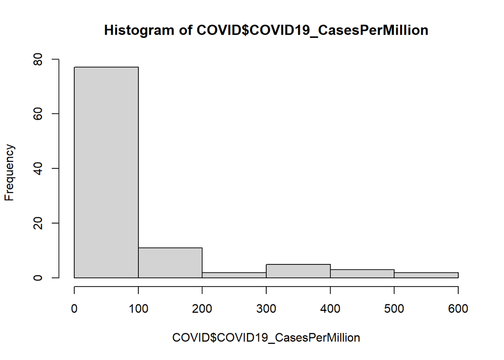

```r
hist(COVID$COVID19_CasesPerMillion, breaks = 6)
```

A hisztogram alakjának főbb tendenciái (sok kis érték, egyre inkább kevés nagy érték) megamaradnak, csak a diagram kevésbé részletes a csökkentett kategóriaszám ($k$) miatt.